# ManyBabies 1: Pilot Data Analysis

Mike Frank, Hugh Rabagliati, and others

Mike Frank (edits by Hugh Rabagliati and Melissa Kline)

This document shows an analysis of MB1 pilot data for purposes of procedural and analytic decision-making. It includes analysis of demographics and looking times, as well as condition differences. *Condition differences (i.e., analyses of IDS preference) are included for purposes of analysis planning and should not be used for modification of procedure.*

Please forgive errors, omissions, lack of clearly labeled axes, etc. This document was produced quickly to provide an initial guide for decision-making.

There are many decision-points that need to be discussed throughout. Among them:

- What format to ask for data in?
- What to do with minimum looking time trials (e.g., record as 2s, record as 0s, exclude)
- What trials to include in the analysis (e.g., should we include non-looking trials at the end of the experiemnt)?

What if any modifications/clarifications to procedure should we make based on the pilot? *sorry if any of this was already discussed/decided -mk*

- Trial ordering: looks like many labs will use the ‘small set of randomized lists’ approach; to avoid odd item/trial effects it would be good if 12345678 was not everyone’s base list.
- Trial naming: what counts as a trial? E.g. is IDS5 followed by ADS5 ‘trial 1, trial 2’, or is it ‘trial 1, order IDSfirst’ This is currently inconsistent between labs.

```r
options(dplyr.width = Inf)
knitr::opts_chunk$set(message = FALSE, warning = FALSE, cache=FALSE)
library(lme4)
library(tidyverse)
library(stringr)
library(lubridate)
library(bit64) # necessary because of times from SMI > max integer size
library(langcog)
library(knitr)
library(forcats)
source("et_helper.R")

theme_set(theme_bw())
```

# 1 Load data

Loading process to standardize pilot data from each lab. Current desideratum is a long-form data sheet with columns:

- `lab` [string] - unique identifier
- `method` [string] - `eye-tracking`, `HPP`, `single screen`
- `subid` [string] - unique within-lab ID
- `age_days` [integer] - chronological age
- `trial_type` [string] - `IDS`, `ADS`, and `training`
- `trial_num` [integer] - trial number, from 1 – 8 (with -2 and -1 denoting training trials)
- `trial_order` [string] - which stim version played first, `IDSfirst` or `ADSfirst` *or label trials 1—16 for individual sounds*
- `stim_name` [string] - specific stimulus, eg. `ADS-5`
- `looking_time` [double] - looking time in seconds

In general, we probably want to have three different spreadsheets:

- `labs` - this has lab and method info
- `subjects` - this has demographics for each subject
- `trials` - this has long-form trial data

Then these can be merged appropriately.

*Questions*:

- Do we want order in here? Probably. *yes -mk*
- Do we want specific stimulus? Likely yes as well. *agree*

## 1.1 Frank data

Read in eye-tracker pilot data.

```r
raw_data_path <- "pilot/frank/"
info_path <- "info/"
processed_data_path <- "processed_data/frank/"

all_data <- dir(raw_data_path, pattern="*.txt") %>%
  paste0(raw_data_path, .) %>%
  map_df(get_smi_header) %>%
  split(.$file_name) %>%
  map_df(read_smi_idf) %>%
  split(.$file_name) %>%
  map_df(preprocess_data)
```

Now extract trial numbers and match with stimuli.

Some items to be fixed:

- Currently we’re not actually matching stimuli to trials (this will require parsing eye-tracker XML output)
- We’re missing trial ADS-7; that’s a (major) oversight from the experimental setup.
- Right now I clip trials < 5, which trims out the two training trials.

```r
frank_data <- all_data %>%
  group_by(file_name, trial, stimulus) %>%
  summarise(looking_time = sum(dt[!is.na(x) & !is.na(y)]),
            looking_time = ifelse(is.na(looking_time), 0, looking_time)) %>%
  mutate(trial_cat = ifelse(str_detect(stimulus, ".jpg"), "speech","other")) %>%
  filter(trial_cat == "speech") %>%
  group_by(file_name) %>%
  filter(trial > 5) %>%
  mutate(trial_num = 1:n(),
         subid = str_replace(str_replace(file_name,raw_data_path,""),
                           ".txt",""))
```

Now merge in demographic information.

```r
suppressWarnings(info <- read_csv("info/frank_demo.csv", col_types = cols()))

frank_data <- info %>%
  select(subid, age, order) %>%
  left_join(frank_data)
```

Now merge in orders.

```r
orders <- suppressWarnings(read_csv("info/orders.csv", col_types = cols())) %>%
  gather(marker, stimulus, 2:19) %>%
  rename(order = Order) %>%
  filter(!str_detect(stimulus, "Train")) %>%
  group_by(order) %>%
  mutate(trial_num = 1:n()) %>%
  separate(stimulus, into = c("trial_type", "stim_num"), sep = -2) %>%
  select(-marker, -stim_num)

frank_data <- left_join(frank_data, orders) %>%
  mutate(trial_num = ceiling(trial_num  / 2)) %>%
  mutate(age_days = as.numeric(age),
         lab = "stanford",
         method = "eye-tracking") %>%
  select(lab, method, subid, age_days, trial_type, trial_num, looking_time)
```

## 1.2 Floccia data

```r
floccia_data <- suppressWarnings(read_csv("pilot/floccia/pilot data.csv",
                                          col_types = cols())) %>%
  rename(age_days = age,
         looking_time = LT) %>%
  mutate(subid = as.character(id),
         method = "HPP",
         stimulus = str_replace(str_replace(stimulus, ".wav", ""),
                                "Manybabies\\\\", "")) %>%
  separate(stimulus, into = c("trial_type", "stim_num"), sep = "-") %>%
  mutate(trial_num = ceiling(trial/2)) %>%
  select(lab, method, subid, age_days, trial_type, trial_num, looking_time)
```

## 1.3 Hamlin data

```r
hamlin_path <- "pilot/hamlin/"
hamlin_data <- dir(hamlin_path, pattern="*.csv") %>%
  paste0(hamlin_path, .) %>%
  map_df(function(x) {suppressWarnings(read_csv(x, col_types = cols())) %>%
      mutate(order = x)}) %>%
  mutate(order = as.numeric(str_replace(str_replace(order, ".csv",""),
                                        "pilot/hamlin/order",""))) %>%
  gather(trial, looking_time,
         starts_with("Train"), starts_with("IDS"), starts_with("ADS")) %>%
  separate(trial, into = c("trial_type","trial_num"), sep = -2) %>%
  mutate(lab = "ubc",
         method = "single-screen",
         trial_num = as.numeric(trial_num),
         age_days = str_split(age, ";") %>%
           map_dbl(function(x) as.numeric(x[1]) * 30.3 + as.numeric(x[2]))) %>%
  rename(subid = subnum) %>%
  select(lab, method, subid, age_days, trial_type, trial_num, looking_time)
```

## 1.4 Gonzalez-Gomez data

```r
gonzalez_data <- suppressWarnings(read_csv("pilot/gonzalez/long_data.csv",
                                           col_types = cols())) %>%
  mutate(lab = "brookes",
         method = "single-screen",
         subid = SubjectID,
         age_days = as.numeric(str_replace(age_mo, "m", ""))*30.3,
         trial_type = ifelse(str_detect(StimName, "trial"), "Train",
                             ifelse(str_detect(StimName, "IDS"), "IDS", "ADS")),
         trial_num = floor((Trial+1)/2),
         looking_time = TotalLook/1000) %>%
  select(lab, method, subid, age_days, trial_type, trial_num, looking_time)
```

## 1.5 Merge all data

This is what the eventual data frame looks like:

```r
d <- bind_rows(floccia_data, hamlin_data, frank_data, gonzalez_data)
kable(head(d))
```

| lab | method | subid | age_days | trial_type | trial_num | looking_time |
| --- | --- | --- | --- | --- | --- | --- |
| plymouth | HPP | 1 | 331 | IDS | 1 | 20.194 |
| plymouth | HPP | 1 | 331 | ADS | 1 | 20.199 |
| plymouth | HPP | 1 | 331 | IDS | 2 | 2.715 |
| plymouth | HPP | 1 | 331 | ADS | 2 | 16.488 |
| plymouth | HPP | 1 | 331 | ADS | 3 | 18.237 |
| plymouth | HPP | 1 | 331 | IDS | 3 | 13.777 |

# 2 Descriptives and Exclusions

```r
d %>%
  group_by(lab, age_days, subid) %>%
  distinct %>%
  group_by(lab) %>%
  summarise(n = n(),
            age_months = mean(age_days)/30.3) %>%
  kable(digits = 1)
```

[output not shown]

This is an important decision-point. At least we want to exclude:

- Children with no looking time
- Trials with no looking time

```r
lt_totals <- d %>%
  group_by(lab, subid) %>%
  summarise(total_looking_time = sum(looking_time, na.rm=TRUE))

d <- d %>%
  left_join(lt_totals) %>%
  filter(total_looking_time != 0,
         !is.na(total_looking_time)) %>%
  mutate(looking_time = ifelse(looking_time == 0, NA, looking_time))
```

## 2.1 Demographics

What’s our participant distribution?

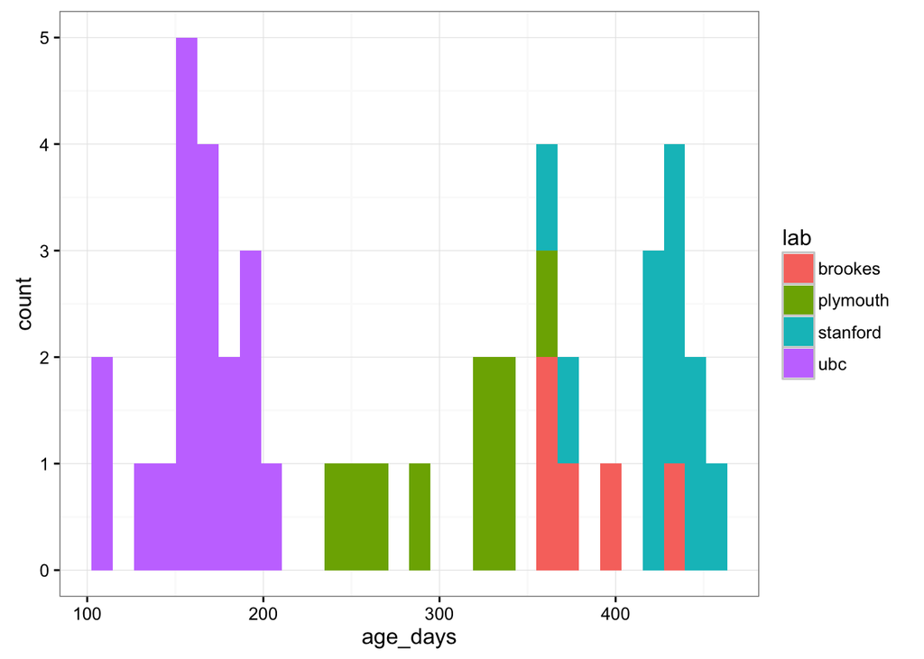

```r
subs <- d %>%
  group_by(lab, subid, age_days) %>%
  distinct

qplot(age_days, fill = lab, data=subs)
```

## 2.2 Looking time dynamics

First, the overall distribution of looking times.

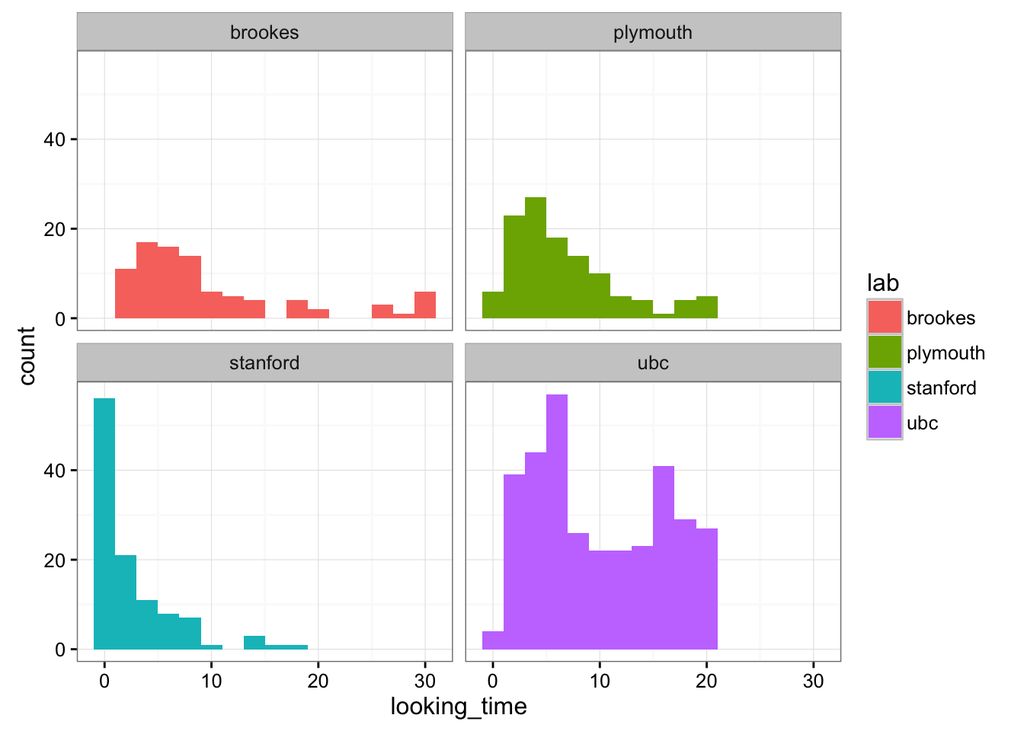

```r
qplot(looking_time, fill = lab, facets = ~ lab, binwidth = 2, data = d)
```

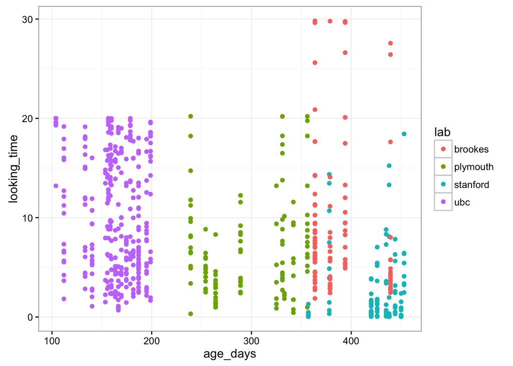

```r
qplot(age_days, looking_time, col = lab, data = d)
```